# Midterm presentation

10/18/2019

## WVS WAVE 7

In 2015 WVSA started planning the 7th wave to be conducted worldwide in 2017-2020. Subsequent waves are planned every five years.

The 7th wave will continue monitoring cultural values, attitudes and beliefs towards gender, family, and religion; attitudes and experience of poverty; education, health, and security; social tolerance and trust; attitudes towards multilateral institutions; cultural differences and similarities between regions and societies. In addition, the WVS-7 questionnaire has been elaborated with the inclusion of such new topics as the issues of justice, moral principles, corruption, accountability and risk, migration, national security and global governance.

## Select following survey questions

q1 - V10: Feeling of happiness  
q2 - V11: State of health (subjective)  
q3 - V23: Satisfaction with your life  
q4 - V24: Most people can be trusted  
q5 - V55: How much freedom of choice and control over own life  
q6 - V56: Do you think most people would try to take advantage of you if they got a chance, or would they try to be fair? people can be trusted  
q7 - V59: Satisfaction with financial situation of household  
q8 - V98: Government responsibility  
q9 - V100: Hard work brings success  
q10 - V170: Secure in neighborhood  
q11 - V237: Family savings during past year  
q12 - V238: Social class (subjective)  
q13 - V240: Sex  
q14 - V242: Age  
q15 - V248: Highest educational level attained

## Rename columns and clean no response data

Since for code -1, -2, -3 here and throughout the interview stand for “Don’t know”, “No answer” and “Not applicable”, we decided to remove such elemtents.

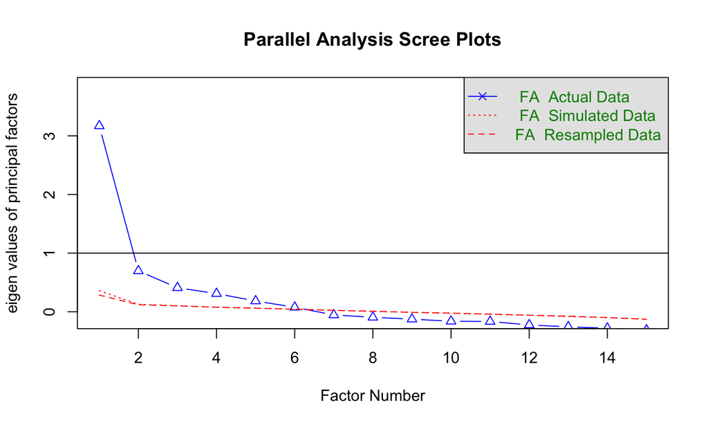

```
## Parallel analysis suggests that the number of factors =  6  and the number of components =  NA
```

The blue line shows eigenvalues of actual data and the two red lines (placed on top of each other) show simulated and resampled data. Here we look at the large drops in the actual data and spot the point where it levels off to the right. Also we locate the point of inflection – the point where the gap between simulated data and actual data tends to be minimum. Looking at this plot and parallel analysis, anywhere between 2 to 6 factors factors would be good choice.

## Factor Analysis

```
##
## Loadings:
##     MR2    MR1    MR3    MR4    MR6    MR5
## q1          0.563
## q2          0.614
## q3         -0.509
## q4                 0.701
## q5                               0.579
## q6                -0.619
## q7   0.773
## q8                                     -0.339
## q9                                      0.495
## q10
## q11 -0.599
## q12 -0.486                0.324
## q13
## q14         0.381
## q15                      -0.627
##
##                  MR2   MR1   MR3   MR4   MR6   MR5
## SS loadings    1.324 1.175 1.001 0.625 0.596 0.536
## Proportion Var 0.088 0.078 0.067 0.042 0.040 0.036
## Cumulative Var 0.088 0.167 0.233 0.275 0.315 0.351
```

```
## R was not square, finding R from data
```

```
## $chisq
## [1] 6302.231
##
## $p.value
## [1] 0
##
## $df
## [1] 105
```

For these data, Bartlett’s test is highly significant, and therefore factor analysis is appropriate. Then, we could get the determinant:

```
## [1] 0.04700017
```

This value is greater than the necessary value of 0.00001. As such, our determinant does not seem problematic.

## Factor extraction (PCA)

For our present purposes we will use principal components analysis (PCA).

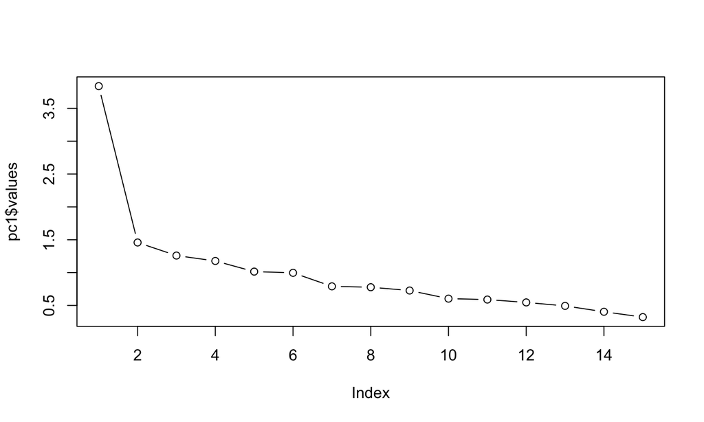

## Redo PCA

Now that we know how many components we want to extract, we can rerun the analysis, specifying that number. To do this, we use an identical command to the previous model but we change nfactors = 15 to be nfactors = 6 because we now want only six factors.

One approach to looking at residuals is just to say that we want the residuals to be small.

```
## [1] 0.4761905
```